# Entregables

- Mostrar todo el código
- Ocultar todo el código
- Ver el código fuente

Autor/a

Denisse Garcia

Fecha de publicación

23 de noviembre de 2026

# Clase 1

## Ejercicio 1 Vectores y selección Pregunta

Crea los vectores `ids <- c("g1", "g2", "g3", "g4", "g5")` y `tam <- c(90, 450, 310, 120, 600)`.

1. Selecciona el tercer identificador.
2. Recupera los identificadores de genes con longitud de al menos 300.
3. Cuenta cuántos cumplen esa condición sin usar un ciclo.

**Código**

```r
ids <- c("g1", "g2", "g3", "g4", "g5")
tam <- c(90, 450, 310, 120, 600)

tercer <- ids[3]
cat("El tercer indentificador es:", tercer, "\n")
```

```
El tercer indentificador es: g3
```

**Código**

```r
longuitud300 <- ids[tam >= 300]
cat("Los identificadores de genes con longitud de al menos 300 son :", longuitud300, "\n")
```

```
Los identificadores de genes con longitud de al menos 300 son : g2 g3 g5
```

**Código**

```r
cuantos_identificadores <- sum(tam >= 300)
cat("cuántos cumplen que los identificadores de genes con longitud de al menos 300 son :", cuantos_identificadores, "\n")
```

```
cuántos cumplen que los identificadores de genes con longitud de al menos 300 son : 3
```

## Ejercicio 2: Factores

Crea una vector con las letras `A M A B M M B A B B`, donde `A` significa Alto, `B` bajo y `M` medio. Convierte las entradas del vector a factores y especifica que `A > M > B`.

**Código**

```r
altura <- factor(c("A", "M", "A", "B", "M", "M", "B", "A", "B", "B"),
            levels = c("A", "M", "B" ))
levels(altura)
```

```
[1] "A" "M" "B"
```

## Ejercicio 3. Elegir estructuras

1. Construye un `data.frame` con tres genes, sus longitudes y una etiqueta funcional.
2. Recupera únicamente las filas con longitud mayor que 200.
3. Crea una lista que contenga la tabla y el identificador de una muestra.
4. Explica por qué una matriz de caracteres no sería una buena sustitución para la tabla cuando queremos conservar longitudes numéricas.

**Código**

```r
tabla <- data.frame(
  gen = c("g1", "g2", "g3"),
  longitud = c(100, 350, 500),
  funcion = c("hipotetica", "enzima", "transportador")
)
tabla[tabla$longitud > 200, ]
```

```
  gen longitud       funcion
2  g2      350        enzima
3  g3      500 transportador
```

**Código**

```r
resultado <- list(muestra = "M01", genes = tabla)
resultado$genes
```

```
  gen longitud       funcion
1  g1      100    hipotetica
2  g2      350        enzima
3  g3      500 transportador
```

## Ejercicio 1. Clasificación de un valor

Define una variable `conteo` que represente el número de lecturas asignadas a un gen. Escribe un condicional que imprima:

- `"Dato faltante"` si el valor es `NA`.
- `"Conteo inválido"` si es negativo.
- `"Sin lecturas"` si es cero.
- `"Con lecturas"` si es positivo.

Prueba tu código con `NA`, `-2`, `0` y `15`.

**Código**

```r
conteo <- 15

if (is.na(conteo)) {
  print("Dato faltante")
} else if (conteo < 0) {
  print("Conteo inválido")
} else if (conteo == 0) {
  print("Sin lecturas")
} else {
  print("Con lecturas")
}
```

```
[1] "Con lecturas"
```

## Ejercicio 2. Verificación de conteos

Considera el vector `conteos <- c(8, 0, 13, 5, 0, 21)`. Utiliza las funciones anteriores para:

1. Verificar si todos los valores son no negativos.
2. Determinar si existe al menos un conteo mayor que 20.
3. Obtener las posiciones de los conteos iguales a cero.
4. Crear un vector que indique `"Presente"` o `"Ausente"` según si el conteo es mayor que cero.

**Código**

```r
conteos <- c(8, 0, 13, 5, 0, 21)

all(conteos >= 0)
```

```
[1] TRUE
```

**Código**

```r
any(conteos > 20)
```

```
[1] TRUE
```

**Código**

```r
which(conteos == 0)
```

```
[1] 2 5
```

**Código**

```r
ifelse(conteos > 0, "Presente", "Ausente")
```

```
[1] "Presente" "Ausente"  "Presente" "Presente" "Ausente"  "Presente"
```

## Ejercicio 3. Longitudes de secuencias

A partir del vector:

**Código**

```r
secuencias <- c("ATG", "ATGCGT", "AATTCCGG", "CG")
```

1. Utiliza un ciclo `for` para guardar las longitudes en un vector llamado `longitudes`.
2. Crea otro vector llamado `clasificacion` que contenga `"Corta"` para longitudes menores que 5 y `"Larga"` para longitudes de al menos 5.
3. Muestra ambos vectores.

**Código**

```r
secuencias <- c("ATG", "ATGCGT", "AATTCCGG", "CG")
longitudes <- numeric(length(secuencias))
clasificacion <- character(length(secuencias))

for (i in seq_along(secuencias)) {
  longitudes[i] <- nchar(secuencias[i])

  if (longitudes[i] < 5) {
    clasificacion[i] <- "Corta"
  } else {
    clasificacion[i] <- "Larga"
  }
}

longitudes
```

```
[1] 3 6 8 2
```

**Código**

```r
clasificacion
```

```
[1] "Corta" "Larga" "Larga" "Corta"
```

## Ejercicio 4. Alcanzar una longitud

Imagina que estamos construyendo una secuencia mediante la adición de un nucleótido `"A"` en cada iteración. Escribe un ciclo `while` que comience con una cadena vacía y se detenga cuando la secuencia alcance **8 nucleótidos**. Muestra el resultado final.

**Código**

```r
secuencia <- ""

while (nchar(secuencia) < 8) {
  secuencia <- paste0(secuencia, "A")
}

secuencia
```

```
[1] "AAAAAAAA"
```

**Código**

```r
nchar(secuencia)
```

```
[1] 8
```

## Ejercicio 1: Función 1

Escribe una función llamada `empieza_con` que reciba una secuencia y un prefijo, y determine si la secuencia comienza con ese prefijo. Pruébala con `"ATGCGT"` y los prefijos `"ATG"` y `"TGA"`.

**Código**

```r
empieza_con <- function(secuencia, prefijo){
  startsWith(secuencia, prefijo)
}

empieza_con("ATGCGT", "ATG")
```

```
[1] TRUE
```

## Ejercicio 2: Función 2

Modifica `resumir_adn()` para que también devuelva la proporción de nucleótidos `G` y `C` respecto de la longitud total. Prueba la función con una secuencia no vacía.

**Código**

```r
resumir_adn <- function(id, secuencia) {
  secuencia <- toupper(secuencia)
  bases <- strsplit(secuencia, split = "", fixed = TRUE)[[1]]

  list(
    id = id,
    longitud = nchar(secuencia),
    conteo_gc = sum(bases %in% c("G", "C"))
  )
}

resultado <- resumir_adn("GEN_01", "ATGCGTAA")
resultado
```

```
$id
[1] "GEN_01"

$longitud
[1] 8

$conteo_gc
[1] 3
```

## 🧠 Ejercicio 3: Función 3

Crea una función llamada `clasificar_secuencias` que reciba un vector de secuencias y devuelva una lista con dos elementos:

- `validas`: las secuencias formadas únicamente por `A`, `C`, `G` y `T`.
- `invalidas`: las secuencias que contienen otros caracteres o valores faltantes.

Utiliza la función `revisar_secuencias()` del ejemplo anterior.

**Código**

```r
clasificacion_secuencias <- function(secuencias) {
  resultado <- logical(length(secuencias))

  for (i in seq_along(secuencias)) {
    secuencia <- secuencias[i]

    if (is.na(secuencia)) {
      resultado[i] <- FALSE
    } else {
      resultado[i] <- grepl("^[ACGT]+$", toupper(secuencia))
    }
  }

  # Calculamos el conteo al finalizar el bucle
  validas <- sum(resultado)
  invalidas <- length(secuencias) - validas

  # Devolvemos tanto el vector booleano como el resumen en una lista
  list(
    vector_resultado = resultado,
    validas = validas,
    invalidas = invalidas
  )
}


secuencias <- c("ATGCGT", "ACNTGA", "ttacga", NA)
clasificacion_secuencias(secuencias)
```

```
$vector_resultado
[1]  TRUE FALSE  TRUE FALSE

$validas
[1] 2

$invalidas
[1] 2
```

## Ejercicio 4

Un archivo de secuencias ha sido representado en R mediante dos vectores:

**Código**

```r
ids <- c("seq_01", "seq_02", "seq_03", "seq_04")
secuencias <- c("ATGCGT", "ACNTGA", "GGCCAA", "TTTAAA")
```

Escribe una función crear_reporte_secuencias(ids, secuencias) que:

Compruebe que ambos argumentos son vectores de caracteres y tienen la misma longitud. Identifique las secuencias válidas mediante revisar_secuencias(). Devuelva un data.frame con las columnas id, secuencia, longitud y valida. Asigne NA a la longitud de las secuencias inválidas.

**Código**

```r
# Función
revisar_secuencias <- function(secuencias) {
  resultado <- logical(length(secuencias))

  for (i in seq_along(secuencias)) {
    secuencia <- secuencias[i]

    if (is.na(secuencia)) {
      resultado[i] <- FALSE
    } else {
      resultado[i] <- grepl("^[ACGT]+$", toupper(secuencia))
    }
  }

  resultado
}

# Función solicitada en el Ejercicio 4
crear_reporte_secuencias <- function(ids, secuencias) {
  # 1. Comprobar que ambos argumentos son vectores de caracteres y tienen la misma longitud
  if (!is.character(ids) || !is.character(secuencias)) {
    stop("Los argumentos 'ids' y 'secuencias' deben ser vectores de caracteres.")
  }

  if (length(ids) != length(secuencias)) {
    stop("Los vectores 'ids' y 'secuencias' deben tener la misma longitud.")
  }

  # 2. Identificar las secuencias válidas mediante revisar_secuencias()
  valida <- revisar_secuencias(secuencias)

  # 4. Calcular longitudes y asignar NA a las secuencias inválidas
  longitud <- nchar(secuencias)
  longitud[!valida] <- NA

  # 3. Devolver un data.frame con las columnas id, secuencia, longitud y valida
  data.frame(
    id = ids,
    secuencia = secuencias,
    longitud = longitud,
    valida = valida,
    stringsAsFactors = FALSE
  )
}

# Prueba
ids <- c("seq_01", "seq_02", "seq_03", "seq_04")
secuencias <- c("ATGCGT", "ACNTGA", "GGCCAA", "TTTAAA")

crear_reporte_secuencias(ids, secuencias)
```

```
      id secuencia longitud valida
1 seq_01    ATGCGT        6   TRUE
2 seq_02    ACNTGA       NA  FALSE
3 seq_03    GGCCAA        6   TRUE
4 seq_04    TTTAAA        6   TRUE
```

## Ejercicio 1

Considera el siguiente código, guardado en un archivo llamado revision.R:

**Código**

```r
longitudes <- nchar(secuencias)
resultado <- data.frame(id = ids, longitud = longitudes)
print(resultado)
```

```
      id longitud
1 seq_01        6
2 seq_02        6
3 seq_03        6
4 seq_04        6
```

Un estudiante afirma que el archivo funciona porque obtuvo una tabla al ejecutarlo en su computadora.

**Por qué podría fallar si otra persona abre el archivo y lo ejecuta desde una sesión nueva de R?** Por que el codigo solo sirve si ya tienes declarado secuencias y ids ya que los pasas como argumentos. Al ejecutarlo el estudiante obtubo una tabla ya que en su ambiente ya tenia los objetos. Por eso al ejecuarlo desde una sesion de R que su ambiente este vacio va a fallar.

**¿Cómo se puede modificar el script para que pueda ejecutarse completo sin depender de objetos creados previamente en la consola?** Se tiene que poner que contiene secuencias y ids en el mismo script

# Clase 2

Ejercicio 1: Reconocer un archivo antes de importarlo

Sin abrirlo en una hoja de cálculo, utiliza R para comprobar que existe blast_separador_incorrecto.csv, mostrar sus tres primeras líneas y determinar qué separador utiliza realmente.

**Código**

```r
file.exists("/Users/dxgarcia/Universidad/Semestre3/bioinformatica3/Intro_R/data_raw/datos_sesion_02_blast/blast_separador_incorrecto.csv")
```

```
[1] TRUE
```

**Código**

```r
blast_separador_incorrecto.csv <- "/Users/dxgarcia/Universidad/Semestre3/bioinformatica3/Intro_R/data_raw/datos_sesion_02_blast/blast_separador_incorrecto.csv"

readLines(blast_separador_incorrecto.csv, n = 5)
```

```
[1] "query_id\tsubject_id\tpident\tlength\tevalue\tbitscore"
[2] "seq01\tref_001\t87.9\t216\t1.00e-40\t118.7"
[3] "seq01\tref_002\t68.2\t245\t1.00e-36\t184.6"
[4] "seq01\tref_003\t93.5\t168\t1.00e-35\t386.1"
[5] "seq02\tref_004\t82.6\t111\t1.00e-85\t259.9"
```

El archivo `blast_separador_incorrecto.csv` ocuoa un separador de tabuladores.

## Ejercicio 2: Elegir la función adecuada

Importa metadata_secuencias.csv y blast_comentarios.tsv utilizando readr. Conserva codigo_muestra como texto. Comprueba la clase de cada objeto y muestra sus primeras filas.

**Código**

```r
library(readr)

metadata_secuencias <- readr::read_tsv("/Users/dxgarcia/Universidad/Semestre3/bioinformatica3/Intro_R/data_raw/datos_sesion_02_blast/metadata_secuencias.csv")

blast_comentarios <- readr::read_tsv("/Users/dxgarcia/Universidad/Semestre3/bioinformatica3/Intro_R/data_raw/datos_sesion_02_blast/blast_comentarios.tsv")

head(metadata_secuencias)
```

```
# A tibble: 6 × 1
  `query_id,organismo,origen,codigo_muestra`
  <chr>
1 seq01,Bacteria_A,suelo,001
2 seq02,Bacteria_B,agua,002
3 seq03,Bacteria_C,suelo,003
4 seq04,Bacteria_A,agua,004
5 seq05,Bacteria_B,suelo,005
6 seq06,Bacteria_C,agua,006
```

**Código**

```r
head(blast_comentarios)
```

```
# A tibble: 6 × 1
  `# Resultado ilustrativo, no generado por BLAST`
  <chr>
1 "# Columnas: query_id, subject_id, pident, length, evalue, bitscore"
2 "query_id\tsubject_id\tpident\tlength\tevalue\tbitscore"
3 "seq01\tref_001\t87.9\t216\t1.00e-40\t118.7"
4 "seq01\tref_002\t68.2\t245\t1.00e-36\t184.6"
5 "seq01\tref_003\t93.5\t168\t1.00e-35\t386.1"
6 "seq02\tref_004\t82.6\t111\t1.00e-85\t259.9"
```

## Ejercicio 3: Explorar resultados tipo BLAST

¿Cuántos registros y columnas tiene la tabla?

**Código**

```r
blast <- read.delim("/Users/dxgarcia/Universidad/Semestre3/bioinformatica3/Intro_R/data_raw/datos_sesion_02_blast/resultados_blast.tsv")
metadata <- read.csv("/Users/dxgarcia/Universidad/Semestre3/bioinformatica3/Intro_R/data_raw/datos_sesion_02_blast/metadata_secuencias.csv",
                     colClasses = c(codigo_muestra = "character"))

nrow(blast)      # Número de filas
```

```
[1] 20
```

**Código**

```r
dim(blast)       # Filas y columnas
```

```
[1] 20  6
```

¿Cuántos query_id diferentes aparecen?

**Código**

```r
length(blast$query_id)
```

```
[1] 20
```

¿Cuántos resultados tiene cada consulta?

**Código**

```r
table(blast$query_id)
```

```
seq01 seq02 seq03 seq04 seq05 seq06 seq07 seq08
    3     2     4     1     3     2     3     2
```

¿Qué filas tienen pident mayor o igual a 95?

**Código**

```r
blast[blast$pident >= 95, ]
```

```
   query_id subject_id pident length evalue bitscore
8     seq03    ref_009   97.8    191  1e-71     97.9
9     seq03    ref_010   99.0    229  1e-08    335.9
16    seq07    ref_019   95.7    106  1e-70    138.5
```

¿Hay valores faltantes?

**Código**

```r
anyNA(blast)
```

```
[1] FALSE
```

## Ejercicio 4: Detectar un problema de lectura

**Un estudiante importa blast_separador_incorrecto.csv con read_csv() y obtiene una sola columna. ¿Significa que el archivo contiene una única variable? Explica cómo comprobarlo y corrige la importación.**

No, no significa que tenga unsa sola variable lo que significa es que no ocupaste el separador correcto, entonces el programa no recomoce todas las columnas por que el separados esta incorrecto.

La forma de comprobarlo y arreglarlo es la siguiente

**Código**

```r
blast_separador_incorrecto.csv <- "/Users/dxgarcia/Universidad/Semestre3/bioinformatica3/Intro_R/data_raw/datos_sesion_02_blast/blast_separador_incorrecto.csv"

readLines(blast_separador_incorrecto.csv, n = 5)
```

```
[1] "query_id\tsubject_id\tpident\tlength\tevalue\tbitscore"
[2] "seq01\tref_001\t87.9\t216\t1.00e-40\t118.7"
[3] "seq01\tref_002\t68.2\t245\t1.00e-36\t184.6"
[4] "seq01\tref_003\t93.5\t168\t1.00e-35\t386.1"
[5] "seq02\tref_004\t82.6\t111\t1.00e-85\t259.9"
```

**Código**

```r
blast_separador_incorrecto.csv <- readr::read_tsv( "/Users/dxgarcia/Universidad/Semestre3/bioinformatica3/Intro_R/data_raw/datos_sesion_02_blast/blast_separador_incorrecto.csv")

str(blast_separador_incorrecto.csv)
```

```
spc_tbl_ [20 × 6] (S3: spec_tbl_df/tbl_df/tbl/data.frame)
 $ query_id  : chr [1:20] "seq01" "seq01" "seq01" "seq02" ...
 $ subject_id: chr [1:20] "ref_001" "ref_002" "ref_003" "ref_004" ...
 $ pident    : num [1:20] 87.9 68.2 93.5 82.6 68.7 88.2 93.6 97.8 99 83.9 ...
 $ length    : num [1:20] 216 245 168 111 292 254 319 191 229 162 ...
 $ evalue    : num [1:20] 1e-40 1e-36 1e-35 1e-85 1e-57 ...
 $ bitscore  : num [1:20] 119 185 386 260 323 ...
 - attr(*, "spec")=
  .. cols(
  ..   query_id = col_character(),
  ..   subject_id = col_character(),
  ..   pident = col_double(),
  ..   length = col_double(),
  ..   evalue = col_double(),
  ..   bitscore = col_double()
  .. )
 - attr(*, "problems")=<externalptr>
```

## Ejercicio 5: Reconocer secuencias en FASTA

Utiliza readLines() y grep() para identificar los encabezados de secuencias.fasta. ¿Cuántas entradas FASTA contiene el archivo? Muestra únicamente sus encabezados.

**Código**

```r
lineas <- readLines("/Users/dxgarcia/Universidad/Semestre3/bioinformatica3/Intro_R/data_raw/datos_sesion_02_blast/secuencias.fasta")
head(lineas, 6)
```

```
[1] ">seq01 secuencia_sintetica"
[2] "AACTCGTAGCAGTACGGATCAACTGTTATAAAATGCACCGAGATTGGTGCGAACG"
[3] ">seq02 secuencia_sintetica"
[4] "GACAATCATGTACAGTCACGAGTCCGCAAAACTCCAATTGGAGCAAGCGCTCGGTGTC"
[5] ">seq03 secuencia_sintetica"
[6] "CCCCGGTGGAGAGGTCCAAGGTCACAAAGGTTTCAAACGAATTGAGAATCCAGGCGATTAA"
```

**Código**

```r
encabezados <- grep("^>", lineas, value = TRUE)
encabezados
```

```
[1] ">seq01 secuencia_sintetica" ">seq02 secuencia_sintetica"
[3] ">seq03 secuencia_sintetica" ">seq04 secuencia_sintetica"
[5] ">seq05 secuencia_sintetica" ">seq06 secuencia_sintetica"
[7] ">seq07 secuencia_sintetica" ">seq08 secuencia_sintetica"
```

**Código**

```r
length(encabezados)
```

```
[1] 8
```

## Práctica Final: explorar un conjunto de resultados

**Código**

```r
library(readr)

# ------------------------------------------------------------------------------
# 1. Comprobar que existen los archivos de trabajo

ruta_blast    <- "/Users/dxgarcia/Universidad/Semestre3/bioinformatica3/Intro_R/data_raw/datos_sesion_02_blast/resultados_blast.tsv"
ruta_metadata <- "/Users/dxgarcia/Universidad/Semestre3/bioinformatica3/Intro_R/data_raw/datos_sesion_02_blast/metadata_secuencias.csv"
ruta_fasta    <- "/Users/dxgarcia/Universidad/Semestre3/bioinformatica3/Intro_R/data_raw/datos_sesion_02_blast/secuencias.fasta"

file.exists(ruta_blast)
```

```
[1] TRUE
```

**Código**

```r
file.exists(ruta_metadata)
```

```
[1] TRUE
```

**Código**

```r
file.exists(ruta_fasta)
```

```
[1] TRUE
```

**Código**

```r
# Comprobación conjunta:
all(file.exists(c(ruta_blast, ruta_metadata, ruta_fasta)))
```

```
[1] TRUE
```

**Código**

```r
# ------------------------------------------------------------------------------
# 2. Importar las dos tablas con readr y conservar codigo_muestra como texto

blast <- read_tsv(
  ruta_blast,
  show_col_types = FALSE
)

metadata <- read_csv(
  ruta_metadata,
  col_types = cols(codigo_muestra = col_character()),
  show_col_types = FALSE
)

# ------------------------------------------------------------------------------
# 3. Mostrar dimensiones, nombres y tipos de columnas

# Tabla de resultados BLAST
dim(blast)
```

```
[1] 20  6
```

**Código**

```r
names(blast)
```

```
[1] "query_id"   "subject_id" "pident"     "length"     "evalue"
[6] "bitscore"
```

**Código**

```r
str(blast)
```

```
spc_tbl_ [20 × 6] (S3: spec_tbl_df/tbl_df/tbl/data.frame)
 $ query_id  : chr [1:20] "seq01" "seq01" "seq01" "seq02" ...
 $ subject_id: chr [1:20] "ref_001" "ref_002" "ref_003" "ref_004" ...
 $ pident    : num [1:20] 87.9 68.2 93.5 82.6 68.7 88.2 93.6 97.8 99 83.9 ...
 $ length    : num [1:20] 216 245 168 111 292 254 319 191 229 162 ...
 $ evalue    : num [1:20] 1e-40 1e-36 1e-35 1e-85 1e-57 ...
 $ bitscore  : num [1:20] 119 185 386 260 323 ...
 - attr(*, "spec")=
  .. cols(
  ..   query_id = col_character(),
  ..   subject_id = col_character(),
  ..   pident = col_double(),
  ..   length = col_double(),
  ..   evalue = col_double(),
  ..   bitscore = col_double()
  .. )
 - attr(*, "problems")=<externalptr>
```

**Código**

```r
# Tabla de metadatos
dim(metadata)
```

```
[1] 8 4
```

**Código**

```r
names(metadata)
```

```
[1] "query_id"       "organismo"      "origen"         "codigo_muestra"
```

**Código**

```r
str(metadata)
```

```
spc_tbl_ [8 × 4] (S3: spec_tbl_df/tbl_df/tbl/data.frame)
 $ query_id      : chr [1:8] "seq01" "seq02" "seq03" "seq04" ...
 $ organismo     : chr [1:8] "Bacteria_A" "Bacteria_B" "Bacteria_C" "Bacteria_A" ...
 $ origen        : chr [1:8] "suelo" "agua" "suelo" "agua" ...
 $ codigo_muestra: chr [1:8] "001" "002" "003" "004" ...
 - attr(*, "spec")=
  .. cols(
  ..   query_id = col_character(),
  ..   organismo = col_character(),
  ..   origen = col_character(),
  ..   codigo_muestra = col_character()
  .. )
 - attr(*, "problems")=<externalptr>
```

**Código**

```r
# ------------------------------------------------------------------------------
# 4. Identificar los query_id distintos y contar los resultados por consulta

# Identificadores únicos de consulta
unique(blast$query_id)
```

```
[1] "seq01" "seq02" "seq03" "seq04" "seq05" "seq06" "seq07" "seq08"
```

**Código**

```r
length(unique(blast$query_id))
```

```
[1] 8
```

**Código**

```r
# Frecuencia de resultados por cada query_id (ordenados de mayor a menor)
sort(table(blast$query_id), decreasing = TRUE)
```

```
seq03 seq01 seq05 seq07 seq02 seq06 seq08 seq04
    4     3     3     3     2     2     2     1
```

**Código**

```r
# ------------------------------------------------------------------------------
# 5. Mostrar las filas con pident >= 90 y explicar qué representa este filtro

blast[blast$pident >= 90, ]
```

```
# A tibble: 5 × 6
  query_id subject_id pident length evalue bitscore
  <chr>    <chr>       <dbl>  <dbl>  <dbl>    <dbl>
1 seq01    ref_003      93.5    168  1e-35    386.
2 seq03    ref_008      93.6    319  1e-36     96.6
3 seq03    ref_009      97.8    191  1e-71     97.9
4 seq03    ref_010      99      229  1e- 8    336.
5 seq07    ref_019      95.7    106  1e-70    138.
```

**Código**

```r
# ------------------------------------------------------------------------------
# 6. Leer el FASTA e indicar cuántos encabezados contiene

lineas_fasta <- readLines(ruta_fasta)


encabezados_fasta <- lineas_fasta[startsWith(lineas_fasta, ">")]
encabezados_fasta
```

```
[1] ">seq01 secuencia_sintetica" ">seq02 secuencia_sintetica"
[3] ">seq03 secuencia_sintetica" ">seq04 secuencia_sintetica"
[5] ">seq05 secuencia_sintetica" ">seq06 secuencia_sintetica"
[7] ">seq07 secuencia_sintetica" ">seq08 secuencia_sintetica"
```

**Código**

```r
length(encabezados_fasta)
```

```
[1] 8
```

**Código**

```r
# ------------------------------------------------------------------------------
# 7. Mostrar si alguna de las tablas tiene valores faltantes

anyNA(blast)
```

```
[1] FALSE
```

**Código**

```r
colSums(is.na(blast))
```

```
  query_id subject_id     pident     length     evalue   bitscore
         0          0          0          0          0          0
```

**Código**

```r
anyNA(metadata)
```

```
[1] FALSE
```

**Código**

```r
colSums(is.na(metadata))
```

```
      query_id      organismo         origen codigo_muestra
             0              0              0              0
```

# Clase 3

## Ejercicio 1. Identificación de genes candidatos

**Código**

```r
#Queremos explorar qué genes podrían estar relacionados con la respuesta bacteriana al estrés.

#Utilizando dplyr:
 library(readr)
library(dplyr)

datos <- read_csv(
  "/Users/dxgarcia/Universidad/Semestre3/bioinformatica3/Intro_R/data_raw/expresion_genica_estres.csv",
  show_col_types = FALSE
)

glimpse(datos)
```

```
Rows: 240
Columns: 8
$ sample_id     <chr> "CTL_01", "CTL_02", "CTL_03", "EST_01", "EST_02", "EST_0…
$ condicion     <chr> "Control", "Control", "Control", "Estres", "Estres", "Es…
$ replica       <dbl> 1, 2, 3, 1, 2, 3, 1, 2, 3, 1, 2, 3, 1, 2, 3, 1, 2, 3, 1,…
$ gene_id       <chr> "gene_001", "gene_001", "gene_001", "gene_001", "gene_00…
$ funcion       <chr> "Función desconocida", "Función desconocida", "Función d…
$ longitud_pb   <dbl> 1803, 1803, 1803, 1803, 1803, 1803, 891, 891, 891, 891, …
$ gc_porcentaje <dbl> 58.1, 58.1, 58.1, 58.1, 58.1, 58.1, 43.2, 43.2, 43.2, 43…
$ conteo        <dbl> 1302, 1263, 1368, 892, 953, 1106, 639, 998, 1108, 733, 9…
```

**Código**

```r
#Calcula el conteo promedio de cada gen en cada condición experimental.
resumen11 <- datos %>%
  group_by(gene_id, condicion) %>%
  summarise(
    promedio = mean(conteo)
  )

resumen11
```

```
# A tibble: 80 × 3
# Groups:   gene_id [40]
   gene_id  condicion promedio
   <chr>    <chr>        <dbl>
 1 gene_001 Control      1311
 2 gene_001 Estres        984.
 3 gene_002 Control       915
 4 gene_002 Estres        907.
 5 gene_003 Control       927.
 6 gene_003 Estres       1041.
 7 gene_004 Control      1260.
 8 gene_004 Estres       1799.
 9 gene_005 Control       108.
10 gene_005 Estres        167
# ℹ 70 more rows
```

**Código**

```r
#Organiza los resultados de manera que puedas comparar los promedios de Control y Estrés para cada gen.

comparar <- resumen11 %>%
  group_by(gene_id) %>%
  arrange(desc(promedio))

comparar
```

```
# A tibble: 80 × 3
# Groups:   gene_id [40]
   gene_id  condicion promedio
   <chr>    <chr>        <dbl>
 1 gene_018 Estres       4747.
 2 gene_008 Estres       4140
 3 gene_019 Estres       4020.
 4 gene_017 Estres       2598.
 5 gene_026 Estres       2184.
 6 gene_007 Estres       2160.
 7 gene_036 Estres       2151.
 8 gene_028 Estres       2127.
 9 gene_006 Estres       1956
10 gene_004 Estres       1799.
# ℹ 70 more rows
```

**Código**

```r
#Calcula la razón entre el promedio en Estrés y el promedio en Control.

razon_promedios <- datos %>%
  group_by(gene_id, condicion, funcion) %>%
  summarise(promedio = mean(conteo), .groups = "drop") %>%
  tidyr::pivot_wider(names_from = condicion, values_from = promedio) %>%
  mutate(razon_estres_control = Estres / Control)

print(razon_promedios)
```

```
# A tibble: 40 × 5
   gene_id  funcion                    Control Estres razon_estres_control
   <chr>    <chr>                        <dbl>  <dbl>                <dbl>
 1 gene_001 Función desconocida          1311    984.                0.750
 2 gene_002 Metabolismo de aminoácidos    915    907.                0.992
 3 gene_003 Síntesis de proteínas         927.  1041.                1.12
 4 gene_004 Síntesis de proteínas        1260.  1799.                1.43
 5 gene_005 Regulación transcripcional    108.   167                 1.54
 6 gene_006 Replicación y reparación      946.  1956                 2.07
 7 gene_007 Metabolismo energético        751.  2160.                2.88
 8 gene_008 Metabolismo energético        956.  4140                 4.33
 9 gene_009 Transporte de membrana        179.  1162.                6.50
10 gene_010 Respuesta al estrés          1124.   497                 0.442
# ℹ 30 more rows
```

**Código**

```r
#Identifica los cinco genes con mayor aumento relativo y muestra su anotación funcional.

top5_genes <- razon_promedios %>%
  slice_max(order_by = razon_estres_control, n = 5)


print(top5_genes)
```

```
# A tibble: 5 × 5
  gene_id  funcion                  Control Estres razon_estres_control
  <chr>    <chr>                      <dbl>  <dbl>                <dbl>
1 gene_009 Transporte de membrana      179.  1162.                 6.50
2 gene_029 Metabolismo energético      237.  1318.                 5.57
3 gene_039 Metabolismo energético      312   1717.                 5.50
4 gene_028 Replicación y reparación    452   2127.                 4.71
5 gene_019 Transporte de membrana      868.  4020.                 4.63
```

**Código**

```r
#Pregunta de interpretación: ¿Un gen con un aumento relativo grande necesariamente presenta un conteo alto de lecturas? Justifica tu respuesta.
```

## Ejercicio 2. ¿Qué funciones biológicas predominan?

Queremos investigar cuáles son las funciones biológicas representadas entre los genes con mayores conteos de lecturas.

Utilizando dplyr:

Calcula el conteo promedio de cada gen considerando todas las muestras. Identifica los 15 genes con mayor conteo promedio. Determina cuántos de esos genes pertenecen a cada categoría funcional. Ordena las categorías funcionales de mayor a menor frecuencia. Pregunta de interpretación: ¿La categoría funcional más frecuente entre estos 15 genes necesariamente es la más importante para la bacteria? Explica.

**Código**

```r
library(readr)
library(dplyr)

datos <- read_csv("/Users/dxgarcia/Universidad/Semestre3/bioinformatica3/Intro_R/data_raw/expresion_genica_estres.csv", show_col_types = FALSE)

# 1. Calcular el conteo promedio de cada gen considerando todas las muestras
# 2. Identificar los 15 genes con mayor conteo promedio
# 3 y 4. Contar genes por categoría funcional y ordenar de mayor a menor frecuencia
funciones_top15 <- datos %>%
  group_by(gene_id, funcion) %>%
  summarise(
    conteo_promedio = mean(conteo),
    .groups = "drop"
  ) %>%
  slice_max(order_by = conteo_promedio, n = 15, with_ties = FALSE) %>%
  count(funcion, sort = TRUE, name = "cantidad_genes")

funciones_top15
```

```
# A tibble: 8 × 2
  funcion                    cantidad_genes
  <chr>                               <int>
1 Metabolismo energético                  3
2 Replicación y reparación                3
3 Metabolismo de aminoácidos              2
4 Regulación transcripcional              2
5 Síntesis de proteínas                   2
6 Función desconocida                     1
7 Respuesta al estrés                     1
8 Transporte de membrana                  1
```

Pregunta de interpretación: ¿La categoría funcional más frecuente entre estos 15 genes necesariamente es la más importante para la bacteria? Explica.

No. Que una categoría funcional sea la más frecuente entre los genes con mayor conteo promedio solo refleja una mayor abundancia de transcritos.

## tarea ¿Qué genes destacan dentro de cada muestra?

En un experimento de expresión génica, algunos genes pueden presentar conteos considerablemente mayores que otros dentro de una misma muestra.

Queremos identificar los genes cuyos conteos superan el promedio de su propia muestra.

Utilizando dplyr:

Calcula el conteo promedio de los genes en cada muestra. Agrega a la tabla original una columna llamada promedio_muestra que contenga ese promedio para cada observación, sin eliminar ninguna fila. Identifica los genes cuyo conteo sea al menos el doble del promedio de su muestra. Calcula cuántos genes cumplen esta condición en cada muestra y compara los resultados entre Control y Estrés. Pregunta de interpretación: ¿Por qué es más adecuado comparar cada gen con el promedio de su propia muestra en lugar de utilizar un único promedio calculado con todas las muestras?

**Código**

```r
# 1 y 2. Agregar promedio por muestra sin eliminar ninguna fila
datos_con_promedio <- datos %>%
  group_by(sample_id) %>%
  mutate(promedio_muestra = mean(conteo)) %>%
  ungroup()

# 3. Filtrar genes cuyo conteo sea al menos el doble del promedio de su muestra
genes_destacados <- datos_con_promedio %>%
  filter(conteo >= 2 * promedio_muestra)

# 4. Contar cuántos genes cumplen la condición en cada muestra y comparar condiciones
conteo_por_muestra <- datos_con_promedio %>%
  group_by(sample_id, condicion) %>%
  summarise(
    genes_destacados = sum(conteo >= 2 * promedio_muestra),
    .groups = "drop"
  )

conteo_por_muestra
```

```
# A tibble: 6 × 3
  sample_id condicion genes_destacados
  <chr>     <chr>                <int>
1 CTL_01    Control                  2
2 CTL_02    Control                  0
3 CTL_03    Control                  0
4 EST_01    Estres                   3
5 EST_02    Estres                   4
6 EST_03    Estres                   3
```

**Código**

```r
# Resumen comparativo entre Control y Estrés
conteo_por_muestra %>%
  group_by(condicion) %>%
  summarise(
    muestras = n(),
    promedio_destacados = mean(genes_destacados),
    total_destacados = sum(genes_destacados),
    .groups = "drop"
  )
```

```
# A tibble: 2 × 4
  condicion muestras promedio_destacados total_destacados
  <chr>        <int>               <dbl>            <int>
1 Control          3               0.667                2
2 Estres           3               3.33                10
```

**Pregunta de interpretación: ¿Por qué es más adecuado comparar cada gen con el promedio de su propia muestra en lugar de utilizar un único promedio calculado con todas las muestras?** Comparar cada gen contra el promedio de su propia muestra ajusta por diferencias en la profundidad de secuenciación (tamaño de librería) o cambios globales de expresión entre muestras

# Clase 4

**Código**

```r
preparar_abundancias <- function(tabla, nivel = "genus", umbral = 0.05) {
  niveles_validos <- c(
    "kingdom", "phylum", "class", "order",
    "family", "genus", "species"
  )

  # Validar los argumentos de entrada antes de procesar
  stopifnot(
    nivel %in% niveles_validos,
    is.numeric(umbral), length(umbral) == 1,
    !is.na(umbral), umbral >= 0, umbral <= 1
  )

  # Asignar la etiqueta para los taxones que queden por debajo del 5%
  etiqueta_otros <- if (nivel == "phylum") {
    "Filos < 5%"
  } else if (nivel == "genus") {
    "Géneros < 5%"
  } else {
    "Taxones < 5%"
  }

  # Seleccionar dinámicamente la columna del nivel elegido y etiquetar valores faltantes
  tabla %>%
    mutate(
      taxon = .data[[nivel]],
      taxon = if_else(is.na(taxon) | taxon == "",
                      "Sin clasificar", taxon)
    ) %>% #Sumar los conteos por muestra, hospedero y taxón
    group_by(sample_id, host_name, taxon) %>%
    summarise(conteo = sum(conteo), .groups = "drop") %>%
    group_by(sample_id) %>%
    #Calcular la abundancia relativa respecto al total de lecturas de cada muestra
    mutate(abundancia_relativa = conteo / sum(conteo)) %>%
    ungroup() %>%
    #Reemplazar los taxones con abundancia menor al umbral por la etiqueta agrupadora

    mutate(
      taxon_final = if_else(
        abundancia_relativa < umbral,
        etiqueta_otros,
        taxon
      )
    ) %>%
    # Sumar las abundancias relativas de los taxones agrupados en la categoría residual
    group_by(sample_id, host_name, taxon_final) %>%
    summarise(
      abundancia_relativa = sum(abundancia_relativa),
      .groups = "drop"
    )
}
```

## ejercicio 2

Sin construir otra función, revisa generos_5 y responde:

*¿Qué representa una fila de generos_5?* Una combinación de muestra (sample_id), hospedero (host_name) y categoría taxonómica final (taxon_final), con su abundancia relativa. *¿Por qué un mismo género puede aparecer individualmente en una muestra y dentro de Otros en otra?* Porque el umbral se aplica dentro de cada muestra: la proporción del género puede ser distinta entre muestras. *Si construimos una gráfica de barras apiladas al 100 %, ¿cuánto deben sumar las abundancias relativas de cada muestra? Compruébalo con group_by() y summarise().* Deben sumar 1 ya que equivale a 100% *¿Qué columna nos permite comparar las muestras según la planta hospedera? ¿De dónde proviene?*

**Código**

```r
library(ggplot2)

# Resultados procesados en la sesión anterior
generos_5 <- read_tsv("results/generos_5.tsv")
generos_5 %>%
  group_by(sample_id) %>%
  summarise(total = sum(abundancia_relativa), .groups = "drop")
```

```
# A tibble: 75 × 2
   sample_id   total
   <chr>       <dbl>
 1 ERR5639101  1
 2 SRR11092499 1.000
 3 SRR11092502 1.000
 4 SRR11092506 1.000
 5 SRR11092508 1.000
 6 SRR11092509 1.000
 7 SRR11092511 1
 8 SRR11092512 1.000
 9 SRR11128412 1.000
10 SRR11128413 1.000
# ℹ 65 more rows
```

host_name proviene del archivo de mtadatos.

# Clase 5

## ejercicio 1

Utilizando generos_5 y metadata_riz:

Identifica las plantas hospederas que tienen al menos 5 muestras. Conserva únicamente las muestras correspondientes a esas plantas. Construye una gráfica de barras apiladas de abundancia relativa por género con ggplot2, utilizando facet_wrap() para comparar las plantas hospederas. Personaliza la figura con una paleta de colores adecuada, etiquetas legibles y la categoría “Géneros < 5%” al final de la leyenda.

Para discutir: ¿Qué diferencias observas en la composición taxonómica entre las plantas? ¿Todas las muestras de una misma planta presentan composiciones similares?

**Código**

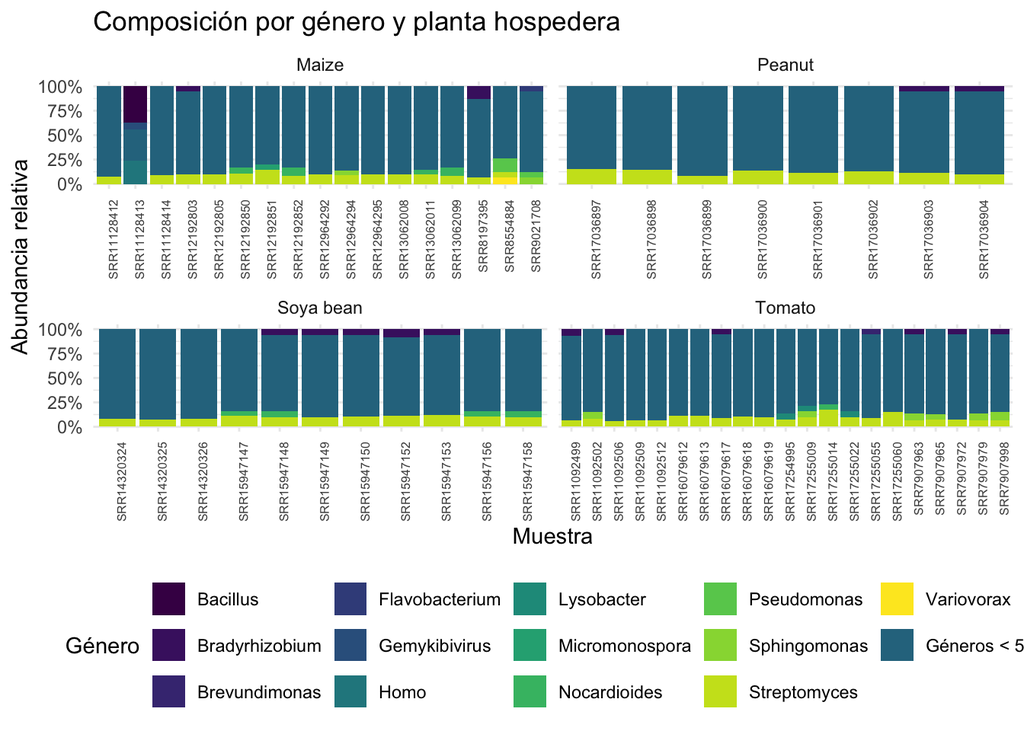

```r
# Metadatos originales
metadata_riz <- read_csv(
  "data_raw/datos_sesion_04_integracion/datos_rizosfera/metadata_rizosfera.csv"
)
# 1. Buscar plantas con al menos 5 muestras
plantas_top <- metadata_riz %>%
  count(host_name) %>%
  filter(n >= 5) %>%
  pull(host_name)

# 2. Filtrar los datos de géneros
datos_ej1 <- generos_5 %>%
  filter(host_name %in% plantas_top)

# 3. Ordenar la leyenda poniendo "Géneros < 5%" al final
orden_gen <- c(
  sort(setdiff(unique(datos_ej1$taxon_final), "Géneros < 5%")),
  "Géneros < 5%"
)

# 4. Hacer la gráfica
ggplot(datos_ej1, aes(x = sample_id, y = abundancia_relativa, fill = taxon_final)) +
  geom_col() +
  scale_fill_viridis_d(breaks = orden_gen) +
  scale_y_continuous(labels = scales::percent) +
  facet_wrap(~ host_name, scales = "free_x") +
  labs(
    title = "Composición por género y planta hospedera",
    x = "Muestra",
    y = "Abundancia relativa",
    fill = "Género"
  ) +
  theme_minimal() +
  theme(
    axis.text.x = element_text(angle = 90, hjust = 1, size = 6),
    legend.position = "bottom"
  )
```

## Ejercicio 2

Utilizando filos_5 y metadata_riz:

Identifica los países que tienen al menos 5 muestras. Conserva únicamente las muestras correspondientes a esos países. Construye una gráfica de barras apiladas de abundancia relativa por filo con ggplot2, utilizando facet_wrap() para comparar los países. Para discutir: ¿Qué diferencias observas en la composición taxonómica entre los países? ¿Las muestras de un mismo país presentan composiciones similares

**Código**

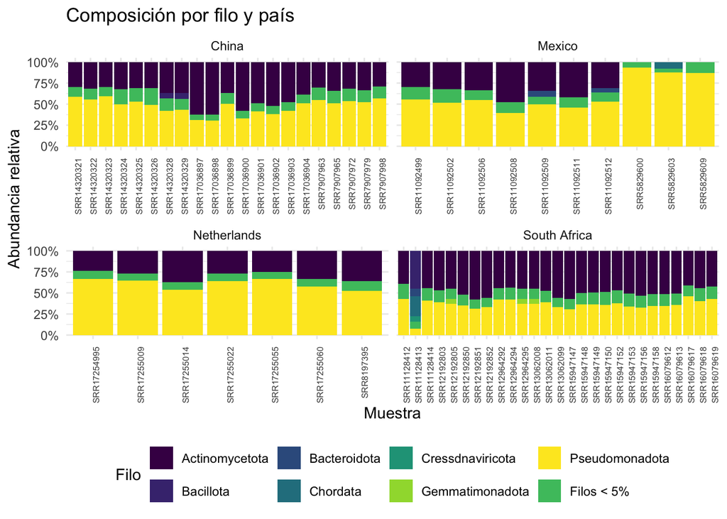

```r
filos_5 <- read_tsv("results/filos_5.tsv")
# 1. Buscar países con al menos 5 muestras
paises_top <- metadata_riz %>%
  count(country) %>%
  filter(n >= 5) %>%
  pull(country)

# 2. Unir el país a filos_5 y filtrar
datos_ej2 <- filos_5 %>%
  left_join(metadata_riz %>% select(sample_id, country), by = "sample_id") %>%
  filter(country %in% paises_top)

# 3. Ordenar la leyenda poniendo "Filos < 5%" al final
orden_fil <- c(
  sort(setdiff(unique(datos_ej2$taxon_final), "Filos < 5%")),
  "Filos < 5%"
)

# 4. Hacer la gráfica
ggplot(datos_ej2, aes(x = sample_id, y = abundancia_relativa, fill = taxon_final)) +
  geom_col() +
  scale_fill_viridis_d(breaks = orden_fil) +
  scale_y_continuous(labels = scales::percent) +
  facet_wrap(~ country, scales = "free_x") +
  labs(
    title = "Composición por filo y país",
    x = "Muestra",
    y = "Abundancia relativa",
    fill = "Filo"
  ) +
  theme_minimal() +
  theme(
    axis.text.x = element_text(angle = 90, hjust = 1, size = 6),
    legend.position = "bottom"
  )
```

Diferencias: Se repiten los mismos filos principales, pero cambian sus porcentajes entre países. Similitud: Solo dentro del mismo estudio o cultivo; cambian mucho si en un país se analizaron plantas distintas.